# PMarquardt_HW11

Paul Marquardt

July 26, 2018

# Question 1: Brief Financial Data

Natively in R, you have access to sample data sets of prominent stocks over time. We’ll be using EuStockMarkets for this question. Type help(EuStockMarkets) to learn more. From these data, pull specifically the DAX index.For all questions in this assignment, you’re welcome to normalize (or don’t!) how you see fit, but, if you choose to, please document what you’re doing and why for the grader.It’s not necessary forthe purpose of this assignment.

1. Obtain the DAX Index from EuStockMarkets dataset

```r
dax <- EuStockMarkets[,"DAX"]
str(dax)
```

```
##  Time-Series [1:1860] from 1991 to 1999: 1629 1614 1607 1621 1618 ...
```

### b)These are annual European Stock Data from 1990 onward. Create a rudimentary plot of the data. Make the line blue. Give an informative title. Label the axes accurately. In 1997, an event happened you want to indicate; add a vertical red line to your plot which divides pre-1997 and post-1997 information.

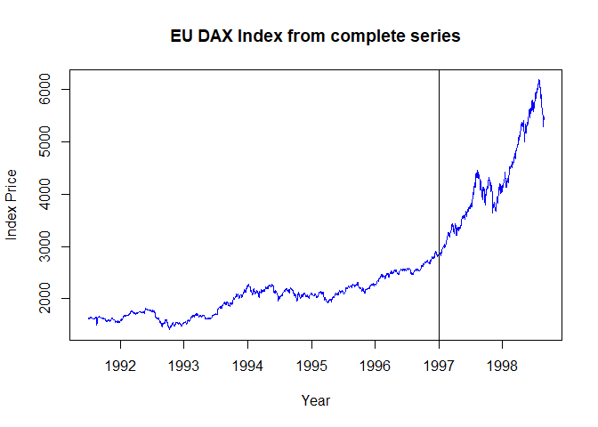

```r
plot(
    dax,
    main="EU DAX Index from complete series",
    xlab="Year",
    ylab="Index Price",
    col="blue"
)
abline(
    v=1997,
    color="red"
)
```

### c) Decompose the time series into its components (i.e., trend, seasonality, random). Keep in mind that this is a multiplicative model you want. Create a plot of all decomposed components. As before, make all lines blue and have a vertical divider at the year 1997.

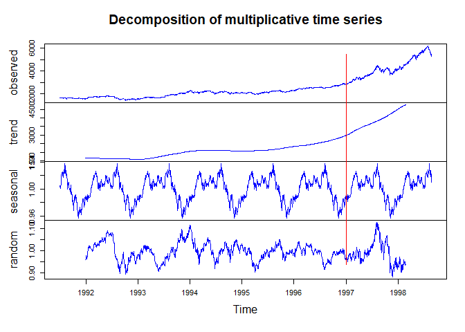

```r
dax.decompose.multi <- decompose(dax,type="multiplicative")
plot(dax.decompose.multi,col="blue")
abline(
    v=1997,
    col="red"
)
```

# Question 2: Temperature Data

### a) Using the maxtemp datasetgranted by loading fpp2, there are maximum annual temperature data in Celsius. For more information, use help(maxtemp). To see what you’re looking at, execute the command in ‘Examples’ in the help document

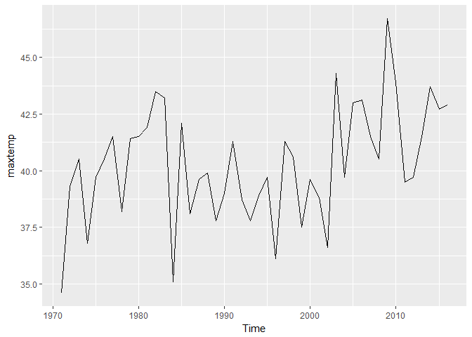

```r
autoplot(maxtemp)
```

### b) We are only concerned with information after 1990. Please eliminate unwanted information or subset information we care about

```r
temps <- window(maxtemp, start = 1990)
```

### c) Utilize SES to predict the next five years of maximum temperatures in Melbourne. Plot this information, including the prior information and the forecast. Add the predicted value line across 1990-present as a separate line, preferably blue. So, to review, you should have your fit, the predicted value line overlaying it, and a forecast

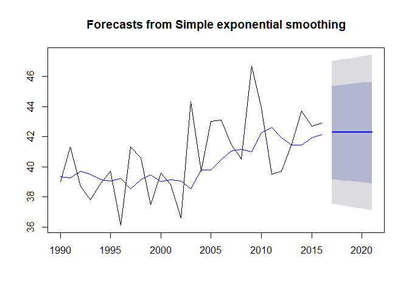

```r
temps.ses <- ses(temps, h=5)
plot(temps.ses)
lines(temps.ses$fitted,col="blue")
```

```r
temps.ses$model$aicc
```

```
## [1] 141.5302
```

### d) Now use a dampedHolt’slinear trend to also predict out five years.Make sure initial=“optimal.” As above, create a similar plot to 1C, but use the Holt fit instead.

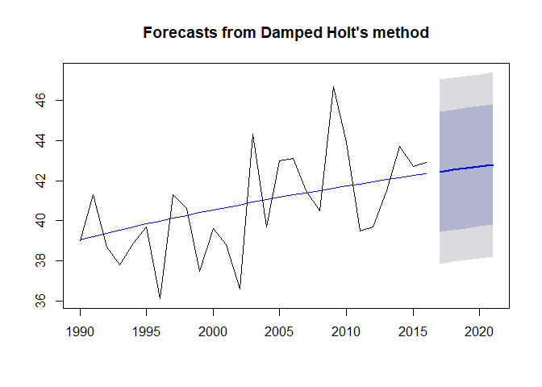

```r
temps.holt <- holt(temps, h=5, damped = TRUE, inital = "optimal")
plot(temps.holt)
lines(temps.holt$fitted,col="blue")
```

```r
temps.holt$model$aicc
```

```
## [1] 145.5865
```

### e) Compare the AICc of the ses() and holt() models. Which model is better here?

```r
temps.ses$model$aicc
```

```
## [1] 141.5302
```

```r
temps.holt$model$aicc
```

```
## [1] 145.5865
```

SES comprises the best model.

# Question 3: The Wands Choose the Wizard

### a) Utilize the dygraphslibrary. Read in both Unit11TimeSeries_Ollivander and _Gregorovitch.csv as two different data frames. They do not have headers, so make sure you account for that.This is a time series of Wands sold over years

```r
gregorovitch <- read.csv("Unit11TimeSeries_Gregorovitch.csv")
ollivander <- read.csv("Unit11TimeSeries_Ollivander.csv")

names(gregorovitch) <- c("year","wands_sold")
names(ollivander) <- c("year","wands_sold")

str(gregorovitch)
```

```
## 'data.frame':    47 obs. of  2 variables:
##  $ year      : Factor w/ 47 levels "1/1/1971","1/1/1972",..: 1 2 3 4 5 6 7 8 9 10 ...
##  $ wands_sold: int  1295 1349 1298 1493 1432 1431 1291 1247 1403 1188 ...
```

```r
str(ollivander)
```

```
## 'data.frame':    47 obs. of  2 variables:
##  $ year      : Factor w/ 47 levels "1/1/1971","1/1/1972",..: 1 2 3 4 5 6 7 8 9 10 ...
##  $ wands_sold: int  1304 1168 1252 1296 1458 1443 1282 1450 1338 1063 ...
```

### b) You don’t have your information in the proper format! In both data sets, you’ll need to first convert the date-like variable to an actual Date class.

```r
gregorovitch$year <- as.Date(gregorovitch$year, "%m/%d/%Y")
ollivander$year <- as.Date(gregorovitch$year, "%m/%d/%Y")

str(gregorovitch)
```

```
## 'data.frame':    47 obs. of  2 variables:
##  $ year      : Date, format: "1971-01-01" "1972-01-01" ...
##  $ wands_sold: int  1295 1349 1298 1493 1432 1431 1291 1247 1403 1188 ...
```

```r
str(ollivander)
```

```
## 'data.frame':    47 obs. of  2 variables:
##  $ year      : Date, format: "1971-01-01" "1972-01-01" ...
##  $ wands_sold: int  1304 1168 1252 1296 1458 1443 1282 1450 1338 1063 ...
```

### c) Use the library xts (and the xts() function in it) to make each data frame an xts object (effectively, a time series). You’ll want to order.by the Date variable.

```r
gregorovitch.ts <- xts(gregorovitch$wands_sold, order.by=gregorovitch$year)
ollivander.ts <- xts(ollivander$wands_sold, order.by=ollivander$year)
str(gregorovitch.ts)
```

```
## An 'xts' object on 1971-01-01/2017-01-01 containing:
##   Data: int [1:47, 1] 1295 1349 1298 1493 1432 1431 1291 1247 1403 1188 ...
##   Indexed by objects of class: [Date] TZ: UTC
##   xts Attributes:
##  NULL
```

```r
str(ollivander.ts)
```

```
## An 'xts' object on 1971-01-01/2017-01-01 containing:
##   Data: int [1:47, 1] 1304 1168 1252 1296 1458 1443 1282 1450 1338 1063 ...
##   Indexed by objects of class: [Date] TZ: UTC
##   xts Attributes:
##  NULL
```

### d) Bind the two xts objects together and create a dygraph from it.Utilize the help() index if you’re stuck

```r
wands.sold <- merge(gregorovitch.ts,ollivander.ts)

dygraph(wands.sold,main="Olivander vs. Gregorovitch Wand Sales",xlab="Year",ylab="Sales") %>%
    dySeries("ollivander.ts", label="Gregorovitch", col="red") %>%
    dySeries("gregorovitch.ts", label="Ollivander",col="blue") %>%
    dyRangeSelector() %>%
    dyShading(from="1995-01-01",to="1999-01-01") %>%
    dyHighlight(highlightSeriesOpts = list( strokeWidth = 3 ) )
```

[interactive chart not shown]